# Session 12: Simple Linear Regression

Mobina Pourmoshir

4/19/2024

# Simple Linear Regression

- Simple linear regression is a statistical method you can use to understand the relationship between two variables, $x$ and $y$.
- One variable, $x$, is known as the predictor (independent) variable.
- The other variable, $y$, is known as the response (dependent) variable.
- Simple linear regression provides an equation between $y$ and $x$.
  - $y = b_0 +b_1\;x + \epsilon$,
  - where $y$: dependent variable,
  - where $x$: independent variable,
  - where $b_0$: y-intercept,
  - where $b_1$: regression coefficient (slope of regression line),
  - where $\epsilon$: error term.
- Estimated simple linear regression equation
  - $\hat{y} = b_0 +b_1\;x$
  - $b_1 = \frac{\sum(x_i-\bar{x})(y_i-\bar{y})}{(x_i-\bar{x})^2}$
  - $b_0 = \bar{y} - b_1\bar{x}$

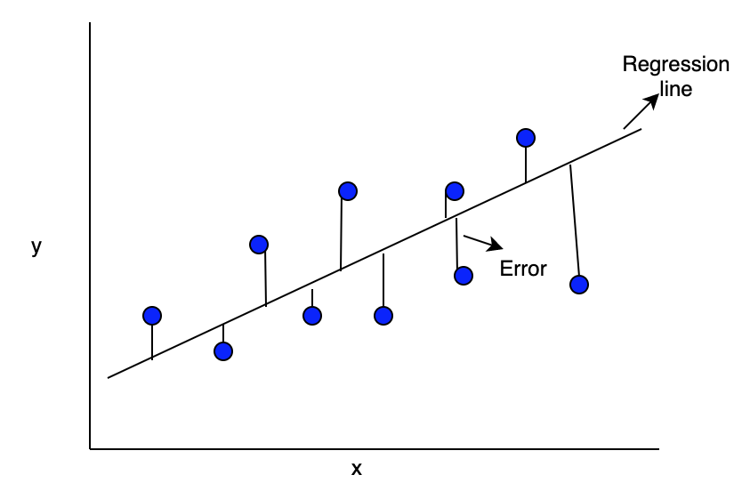

# Example

- For example, suppose we are interested in understanding the relationship between weight and height.

```r
weight <- c(140,155,159,179,192,200,212)
height <- c(60,62,67,70,71,72,75)
```

- Let weight be the predictor variable and let height be the response variable.
  - $\text{Height} = b_0 +b_1\text{weight} + \epsilon$

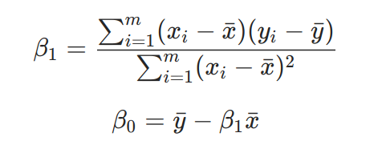

- We graph these two variables using a scatterplot with weight on the x-axis and height on the y-axis.

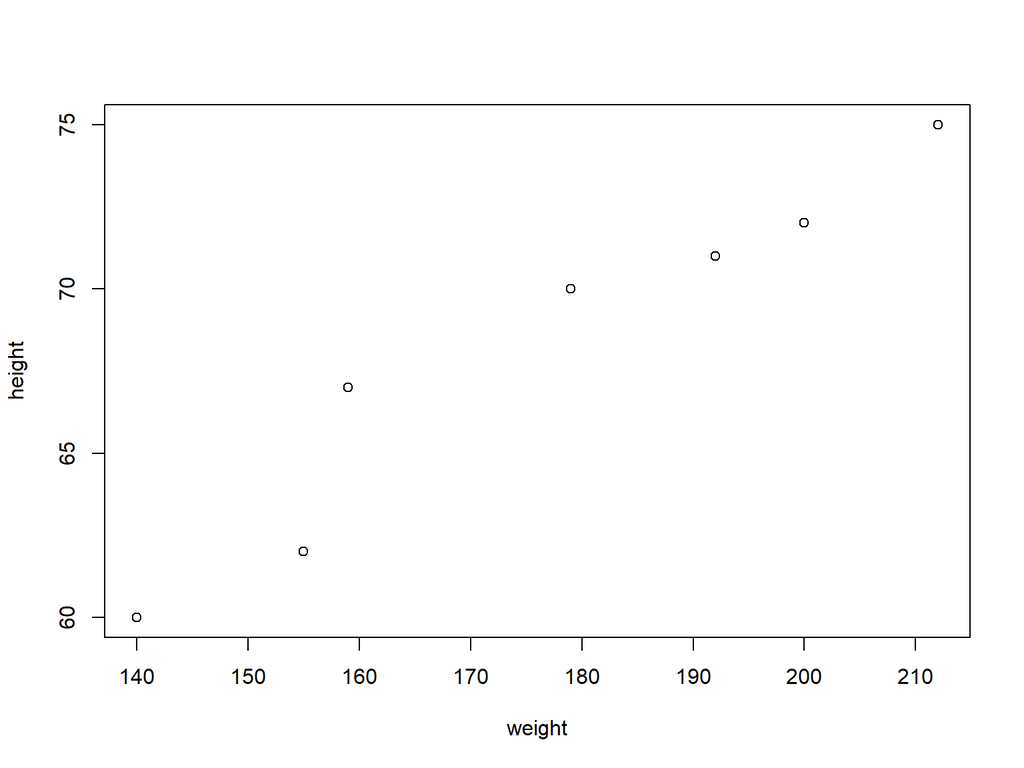

```r
plot(weight,height)
```

- We observe from the scatterplot that as weight increases, height tends to increase as well.
- We use linear regression to quantify this relationship between weight and height.
- We can find the line that best “fits” our data.
- This line is known as the least squares regression line and it can be used to help us understand the relationships between weight and height.

```r
y <- height
x <- weight
ybar <- mean(y)
xbar <- mean(x)
b1 <- sum((x-xbar)*(y-ybar))/sum((x-xbar)^2)
b1
```

```
## [1] 0.2000962
```

```r
b0 <- ybar - b1*xbar
b0
```

```
## [1] 32.78301
```

- $\hat{\text{Height}} =$ 32.7830059 + 0.2000962$\;\text{weight}$

# Assupmtions of Linear Regression

- For the results of a linear regression model to be valid and reliable, we need to check that the following four assumptions are met:
1. Linear relationship: There exists a linear relationship between the independent variable, $x$, and the dependent variable, $y$.
2. Independence: The residuals are independent. In particular, there is no correlation between consecutive residuals in time series data.
3. Homoscedasticity: The residuals have constant variance at every level of $x$.
4. Normality: The residuals of the model are normally distributed.
- If one or more of these assumptions are violated, then the results of our linear regression may be unreliable or even misleading.

# The lm() function

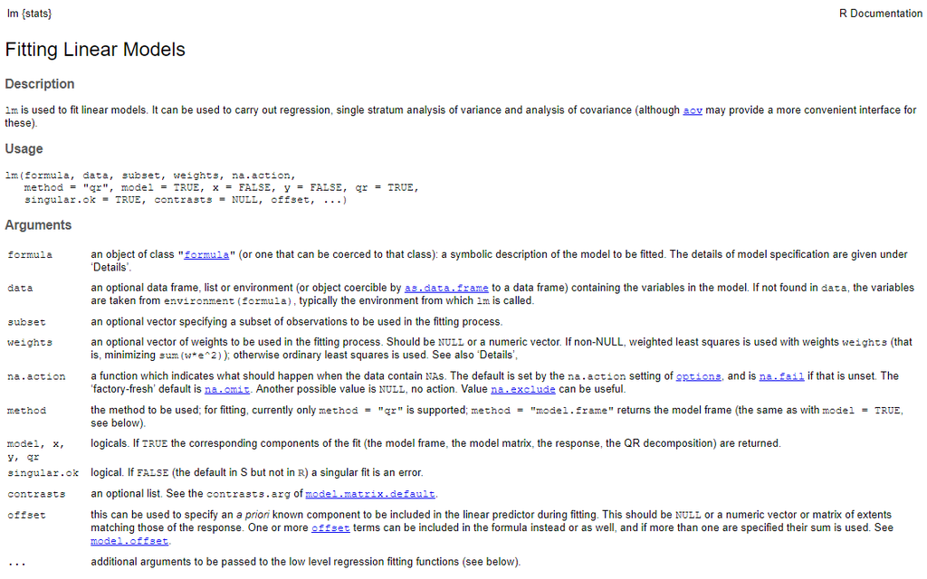

# Example

- Using our height and weight data, we obtain the simple linear regression model using the `lm()` function.
- Use the `summary()` to obtain $R^2$ and `p-value` from the model

```r
lm1 <- lm(height~weight)
summary(lm1)
```

```
##
## Call:
## lm(formula = height ~ weight)
##
## Residuals:
##       1       2       3       4       5       6       7
## -0.7965 -1.7979  2.4017  1.3998 -0.2015 -0.8022 -0.2034
##
## Coefficients:
##             Estimate Std. Error t value Pr(>|t|)
## (Intercept) 32.78301    4.34178   7.551 0.000646 ***
## weight       0.20010    0.02434   8.221 0.000434 ***
## ---
## Signif. codes:  0 '***' 0.001 '**' 0.01 '*' 0.05 '.' 0.1 ' ' 1
##
## Residual standard error: 1.57 on 5 degrees of freedom
## Multiple R-squared:  0.9311, Adjusted R-squared:  0.9173
## F-statistic: 67.59 on 1 and 5 DF,  p-value: 0.0004336
```

- The first entry of the output of `summary()` is a repetition of the function call that created the model.
- The second section of the output reports the residuals.
- The third block is named `Coefficients`. It contains the estimates, standard error of the estimates, test statistics and `p-value`.
- The last section contains more information. `Residual standard error`, `Multiple R-squared`, `Adjusted R-squared`, `F-statistics` and its associated `p-value`.
- $\hat{\text{Height}} = 32.78301 + 0.20010 \text{weight}$

# Goodness of Fit: Coefficient of Determination, $R^2$

- The coefficient of determination, $R^2$, is a measure of the strength of linear association between the two variables.
- $R^2$ is the proportion of the variance in the response (dependent) variable $y$ that can be explained by the variation in the predictor (independent) variable.
- Its value varies between 0 and 1
- A value of 0 indicates that the response variable cannot be explained by the predictor variable at all.
- A value of 1 indicates that the response variable can be perfectly explained without error by the predictor variable.
  - Example, an $R^2$ of 0.2 indicates that 20% of the variance in the response variable can be explained by the predictor variable;
  - An $R^2$ of 0.77 indicates that 77% of the variance in the response variable can be explained by the predictor variable.
- In our previous example of the height and weight data, `Multiple R-squared` is 0.9311. This indicates that 93.11% of the variance in height can be explained by the weight.

# Prediction

- First, we generate the predicted values $\hat{y}$ and call it predicted height.

```r
pred_height <- fitted(lm1)
resid_height <- lm1$residuals
cbind(height, pred_height, resid_height)
```

```
##   height pred_height resid_height
## 1     60    60.79647   -0.7964693
## 2     62    63.79791   -1.7979118
## 3     67    64.59830    2.4017035
## 4     70    68.60022    1.3997802
## 5     71    71.20147   -0.2014700
## 6     72    72.80224   -0.8022393
## 7     75    75.20339   -0.2033933
```

```r
confint(lm1,0.95)
```

```
##      2.5 % 97.5 %
```

- We can predict heights given new weights by using the `predict`.

```r
new_weight <- data.frame(weight <-c(156,165,180,205))
predict(lm1, new_weight)
```

```
##        1        2        3        4
## 63.99801 65.79887 68.80032 73.80272
```

# Example

```r
income.data <- read.csv("C:/Users/PC/OneDrive - Marquette University/Desktop/Spring 2024/MATH 4730 Introduction to R/data_sets/income.data.csv",header = T)
str(income.data)
```

```
## 'data.frame':    498 obs. of  3 variables:
##  $ X        : int  1 2 3 4 5 6 7 8 9 10 ...
##  $ income   : num  3.86 4.98 4.92 3.21 7.2 ...
##  $ happiness: num  2.31 3.43 4.6 2.79 5.6 ...
```

```r
summary(income.data)
```

```
##        X             income        happiness
##  Min.   :  1.0   Min.   :1.506   Min.   :0.266
##  1st Qu.:125.2   1st Qu.:3.006   1st Qu.:2.266
##  Median :249.5   Median :4.424   Median :3.473
##  Mean   :249.5   Mean   :4.467   Mean   :3.393
##  3rd Qu.:373.8   3rd Qu.:5.992   3rd Qu.:4.503
##  Max.   :498.0   Max.   :7.482   Max.   :6.863
```

### Assumption check

1. Homoscedasticity (aka homogeneity of variance) This means that the prediction error doesn’t change significantly over the range of prediction of the model. We can test this assumption later, after fitting the linear model.
2. Linearity

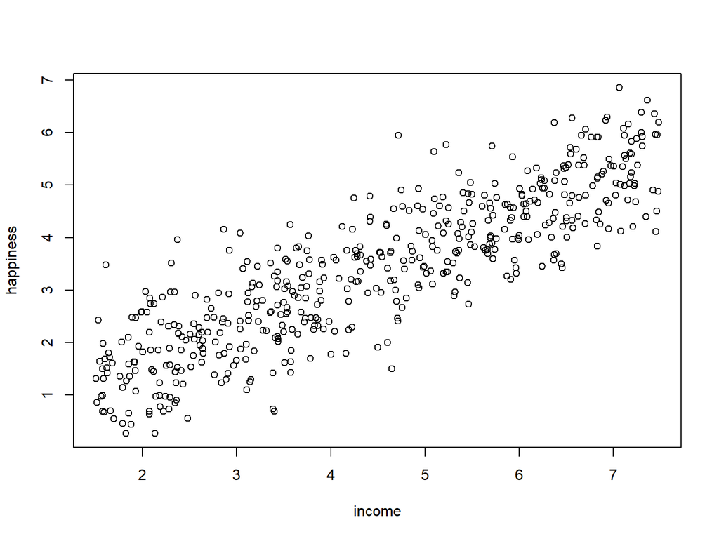

```r
plot(happiness ~ income, data = income.data)
```

3. Normality To check whether the dependent variable follows a normal distribution, use the `hist()` function.

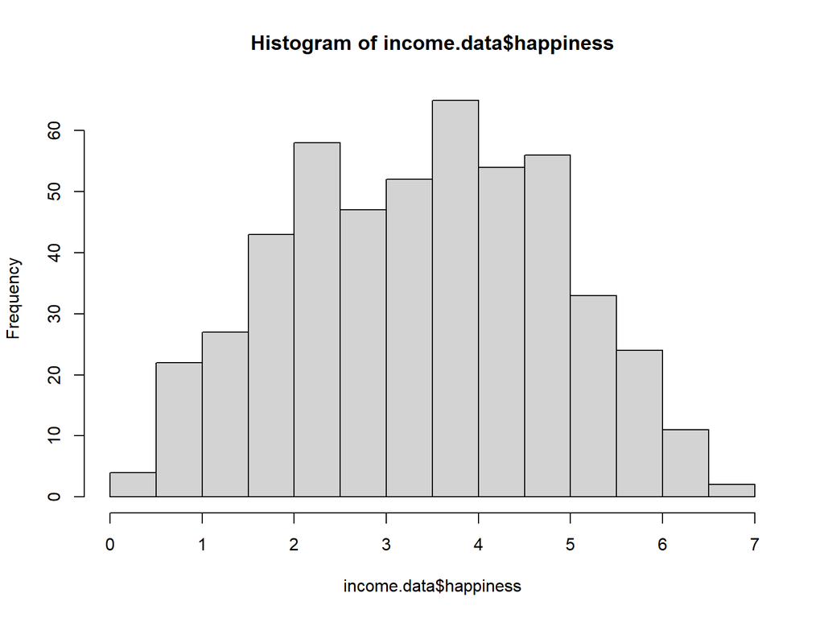

```r
hist(income.data$happiness)
```

4. Independence of observations (aka no autocorrelation) Because we only have one independent variable and one dependent variable, we don’t need to test for any hidden relationships among variables.

If you know that you have autocorrelation within variables (i.e. multiple observations of the same test subject), then do not proceed with a simple linear regression! Use a structured model, like a linear mixed-effects model, instead.

# Model

- We perform a simple linear regression analysis and check the results.

```r
income.happiness.lm <- lm(happiness ~ income, data = income.data)

summary(income.happiness.lm)
```

```
##
## Call:
## lm(formula = happiness ~ income, data = income.data)
##
## Residuals:
##      Min       1Q   Median       3Q      Max
## -2.02479 -0.48526  0.04078  0.45898  2.37805
##
## Coefficients:
##             Estimate Std. Error t value Pr(>|t|)
## (Intercept)  0.20427    0.08884   2.299   0.0219 *
## income       0.71383    0.01854  38.505   <2e-16 ***
## ---
## Signif. codes:  0 '***' 0.001 '**' 0.01 '*' 0.05 '.' 0.1 ' ' 1
##
## Residual standard error: 0.7181 on 496 degrees of freedom
## Multiple R-squared:  0.7493, Adjusted R-squared:  0.7488
## F-statistic:  1483 on 1 and 496 DF,  p-value: < 2.2e-16
```

- From these results, we can say that there is a significant positive relationship between income and happiness ($p value < 0.001$), with a $0.713 - unit (\pm 0.01)$ increase in happiness for every unit increase in income.

# Residual Analysis

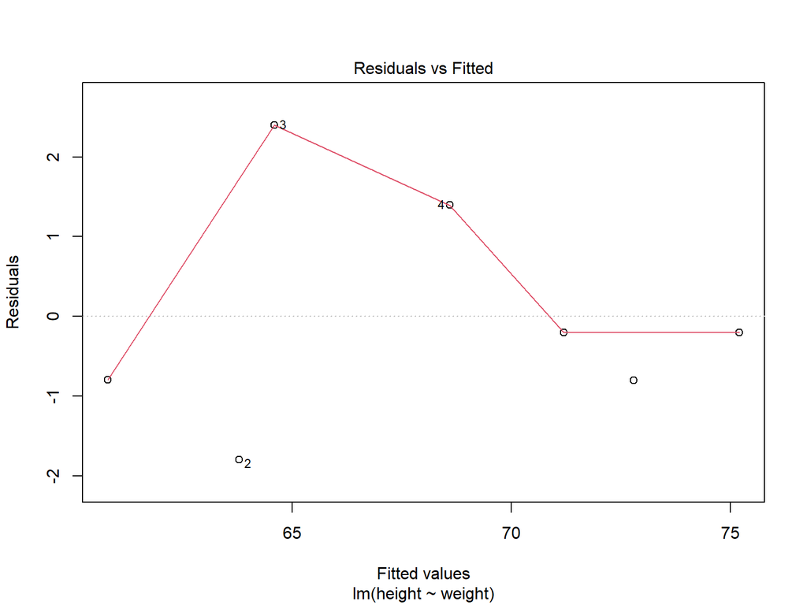

```r
plot(lm1, which=1)
```

# The basic idea of Residual Analysis

- Recall that not all of the data points in a sample will fall right on the least squares regression line:
  $$y=b_0+b_1x$$
- The vertical distance between any one data point $y_i$ and its estimated value $\hat{y}_i$ is its observed “residual”:
  $$e_i=y_i−\hat{y}_i$$
- The assumptions underlying the simple linear regression model are:
  - Linear relationship: There exists a linear relationship between the independent variable, $x$, and the dependent variable, $y$.
  - Independence: The residuals are independent. In particular, there is no correlation between consecutive residuals in time series data.
  - Homoscedasticity: The residuals have constant variance at every level of $x$.
  - Normality: The residuals of the model are normally distributed.
- The purpose of residual analysis, is to understand if the assumptions underlying the correct usage of the regression model are valid.
- Residual analysis involves making residual plots.

# Checking the Basic Regression Assumptions

- We investigate the price of condominium apartments in Winnipeg using the predictor square feet of living area (sqft) using a linear regression model.
- We explore the scatterplot of price against square feet of living area (sqft).
- We use `abline()` to add a regression line to the scatterplot.

```r
winnipeg <- read.csv("C:/Users/PC/OneDrive - Marquette University/Desktop/Spring 2024/MATH 4730 Introduction to R/data_sets/winnipeg_apt.csv")
str(winnipeg)
```

```
## 'data.frame':    14 obs. of  2 variables:
##  $ price: int  299900 214900 284900 249900 159900 231000 254900 324900 199900 304900 ...
##  $ sqft : int  974 947 1065 812 889 958 1050 1403 834 1349 ...
```

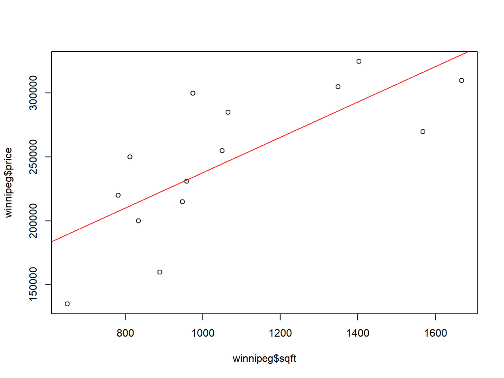

```r
plot(winnipeg$sqft,winnipeg$price)
abline(lm(price~sqft,data=winnipeg),col="red")
```

- By visual inspection, there seem to be a linear relationship between price and square feet of living area (sqft).
- Next we obtain the linear model using the `lm()` function.

```r
lm1 <- lm(price~sqft,data=winnipeg)
lm1
```

```
##
## Call:
## lm(formula = price ~ sqft, data = winnipeg)
##
## Coefficients:
## (Intercept)         sqft
##     99384.5        138.4
```

- The linear relationship can be described using the fitted regression line: `Price= 9.9384548^{4} + 138.3674286*sqft`.
- According to this model the price of apartments in Winnipeg increases by 138.3674286 for each additional square foot increase in living area.

# Checking the Basic Regression Assumptions

- Next, we check independence, normality, and equality of residuals.
- In practice, it is easier to analyze the regression model errors using a residual plot.
- The residual plot is a scatterplot of the residuals and the fitted response values.
- `plot()` function used with the model, in this example lm1, can be helpful in creating a variety of useful plots, including the residuals vs. fitted value scatterplots, by specifying the `which = 1` option.

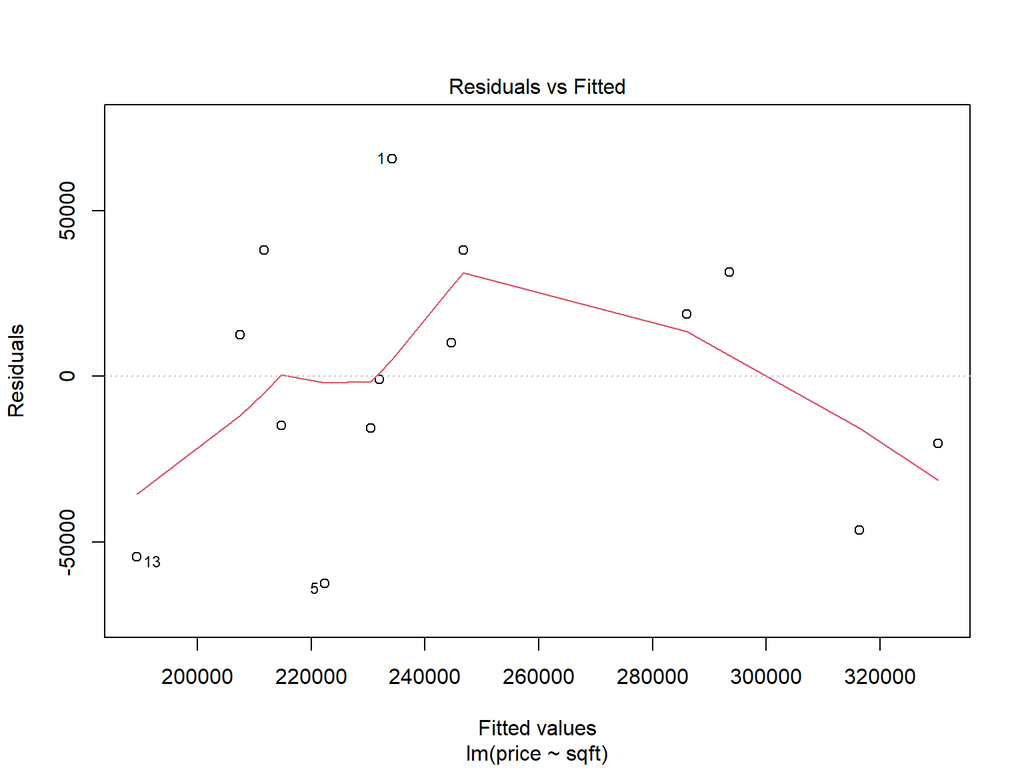

```r
plot(lm1,which=1)
```

- A careful study of the residuals vs fitted plot reveals no obvious pattern which will cause us to question the linear relationship between the price and living area.
- There does not appear to be a curvilinear relationship.
- The variance of the residual terms seems relatively constant.
- No obvious outlier values.
- We can also the `plot()` function to check the normality of the residuals visually using a normal quantile-quantile plot (QQplot) by using the `which = 2` option.

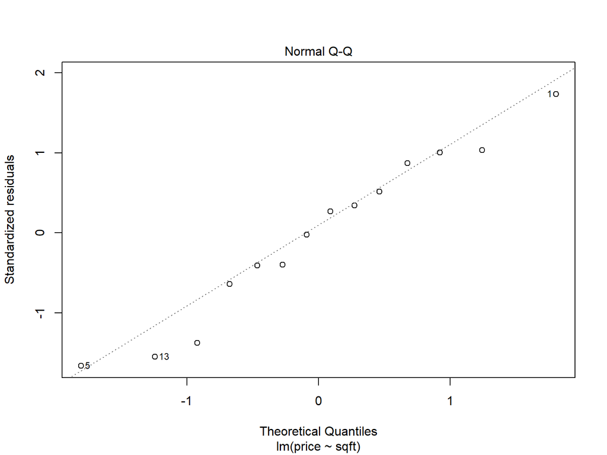

```r
plot(lm1,which=2)
```

- There are a few values lying off the line.
- We conclude that the residuals are normally distributed.
- We have therefore validated the assumptions about the simple linear model.

# Inferences on the regression slope ($b_1$)

- The fitted regression line is given by:
  $$\hat{y}=b_0 + b_1x$$
- When the assumptions of the simple linear regression model are satisfied, a confidence interval for the slope $b_1$ of the population regression line has the form:
  $$(estimated\;slope) \pm
  (t\;critical\;value) \times (standard\; error)$$
- We can use the function `confint()` to construct confidence intervals for the intercept and the slope.
- We are mainly interested in the estimated slope interval.

```r
confint(lm1)  # default 95% confidence interval
```

```
##                   2.5 %      97.5 %
## (Intercept) 13902.00376 184867.0930
## sqft           61.26066    215.4742
```

```r
confint(lm1,level = 0.99)  # default 99% confidence interval
```

```
##                    0.5 %      99.5 %
## (Intercept) -20455.85883 219224.9556
## sqft            30.26926    246.4656
```

- The 99% confidence interval for the slope is (30.26926, 246.4656).
- From this interval, we clearly see that say zero is not a plausible value for the population regression slope on living area of apartment as predictor of price of apartment.
- Hence, the living area of apartment has an influence on the price of apartment.

# Hypothesis testing for the slope ($b_1$)

- The model utility test for simple linear regression is the test of
  $$H_0:b_1=0$$
  $$H_a:b_1\ne 0$$
- The null hypothesis specifies that there is no useful linear relationship between the predictor $x$ and the response $y$.
- If $H_0$ is rejected in favor of $H_a$, we conclude that the simple linear regression model is useful for predicting the response $y$.
- We can use the `summary()` functions to see the tests statistics and p-value for the testing the slope.

```r
summary(lm1)
```

```
##
## Call:
## lm(formula = price ~ sqft, data = winnipeg)
##
## Residuals:
##    Min     1Q Median     3Q    Max
## -62493 -19091   4645  28254  65746
##
## Coefficients:
##             Estimate Std. Error t value Pr(>|t|)
## (Intercept) 99384.55   39233.54   2.533  0.02627 *
## sqft          138.37      35.39   3.910  0.00207 **
## ---
## Signif. codes:  0 '***' 0.001 '**' 0.01 '*' 0.05 '.' 0.1 ' ' 1
##
## Residual standard error: 39510 on 12 degrees of freedom
## Multiple R-squared:  0.5602, Adjusted R-squared:  0.5236
## F-statistic: 15.29 on 1 and 12 DF,  p-value: 0.002073
```

- Using a `0.1%` level of significance $(alpha = 0.001)$, we fail to reject the null hypothesis that the population slope is zero.
- Based on this simple regression model, there is insufficient evidence to conclude that the living area in square feet of a condominium apartment in Winnipeg is useful in predicting the price of the price of the condominium apartment.